# PCA on zebrafish test compendium

J. Taroni for CCDL

2019

The test compendium we have for zebrafish is approximately 50-50 microarray and RNA-seq. In work in the top directory of this repo, we looked into what imputation methodology to use for the species compendium. To do so, we grabbed all the available RNA-seq data at the time and then randomly selected around the same number of processed microarray samples. This is not really representative of what will happen in production. It does allow us to look at any technology differences. First, we’ll do a quick visualization with PCA.

## Setup

#### Packages and functions

```r
# install.packages("ggfortify")
library(ggfortify)
```

```r
`%>%` <- dplyr::`%>%`
```

#### Directories/files

```r
test_compendium_dir <- file.path("refinebio-data", "DANIO_RERIO")
compendium_exprs_file <- file.path(test_compendium_dir, "DANIO_RERIO.tsv")
```

Directory for plots

```r
plot_dir <- "plots"
dir.create(plot_dir, showWarnings = FALSE)
```

## Main

Reading in the compendium expression data

```r
compendium_exprs_df <- readr::read_tsv(compendium_exprs_file)
```

We can *infer* which technology a sample is “part of” from the column names of this `data.frame`.

```r
set.seed(123)
colnames(compendium_exprs_df)[sample(2:ncol(compendium_exprs_df), 6)]
```

```
[1] "fdd22cibxv04m63a0j1n4pky_GSM409446.PCL"
[2] "0d8q150b123yfm6p1a7oxjeg_SRR2138292_output_gene_lengthScaledTPM.tsv"
[3] "83b4j4p8ajwvudtpyza321z8_GSM448956.PCL"
[4] "m04c1iv3crnsjot9eykh993q_SRR5312199_output_gene_lengthScaledTPM.tsv"
[5] "l8oar701xhc95omr2mrmp42q_DRR067137_output_gene_lengthScaledTPM.tsv"
[6] "39aiojuc6biw8plfmttb8k60_GSM1129280_24_CA.PCL"
```

Microarray data will end in `.PCL` and the RNA-seq data ends in `lengthScaledTPM.tsv`. Let’s generate *labels* for the samples using this information.

```r
sample_names <- colnames(compendium_exprs_df)[-1]  # don't want gene id column
compendium_technology_labels <- rep("MICROARRAY", length(sample_names))
compendium_technology_labels[grep("lengthScaledTPM", sample_names)] <- "RNA-SEQ"
```

Get expression values as a matrix

```r
exprs_mat <- compendium_exprs_df %>%
  as.data.frame() %>%
  tibble::column_to_rownames("X1") %>%
  as.matrix()
```

### PCA

```r
pca_results <- prcomp(t(exprs_mat))
```

### Plotting

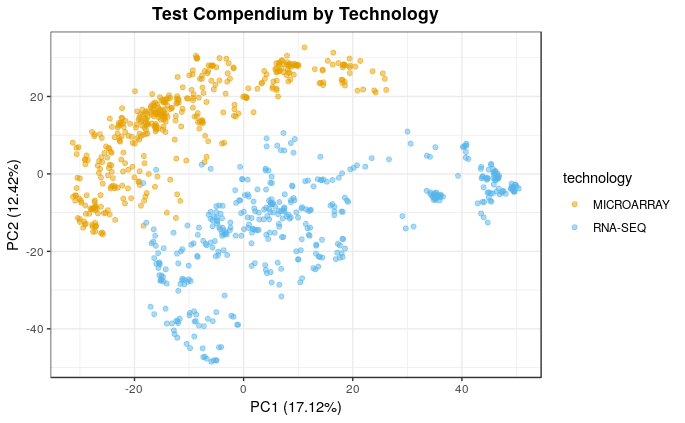

```r
# get the technology labels as a data.frame for plotting
technology_df <- as.data.frame(compendium_technology_labels)
# plotting with autoplot for PCA
autoplot(pca_results, data = technology_df, alpha = 0.5,
         colour = 'compendium_technology_labels', scale = 0) +
  scale_color_manual(labels = c("MICROARRAY", "RNA-SEQ"),
                     values = c("#E69F00", "#56B4E9")) +
  theme_bw() +
  ggtitle("Test Compendium by Technology") +
  theme(plot.title = element_text(hjust = 0.5, face = "bold")) +
  guides(colour = guide_legend(title = "technology"))
```

I’ll note here that because of the way we process RNA-seq data in refine.bio, these RNA-seq samples with *necessarily* be part of the same experiments. There are no such guarantees for the microarray samples. We can see that there are some “clumps” in the RNA-seq, which, if I had to guess, likely correspond to samples from an individual experiment. *Here, I’m using the term “experiment” to refer to what is called a study (e.g., `SRP`, `ERP`, or `DRP`) in SRA.*

Save the plot to file.

```r
ggsave(filename = file.path(plot_dir, "test_compendium_PCA.png"),
       plot = last_plot(), width = 7, height = 5)
```